# Iris Data Analysis

This is the introduction to data analytics, focused on data classfication. The data is pretty simple and clean to complete the introduction to data classification.

The data analysis will start with how to critic the model based on metrics off confusion matrix, then continue with the trial on different classification models, such as decision tree, K nearest neighbors (KNN), random forest and support vector machine.

```python
import pandas as pd
import numpy as np
from sklearn.tree import DecisionTreeClassifier
from sklearn.neighbors import KNeighborsClassifier
from sklearn.ensemble import RandomForestClassifier
from sklearn.svm import SVC
from sklearn.preprocessing import MinMaxScaler, LabelEncoder
from sklearn.model_selection import train_test_split
from sklearn.metrics import confusion_matrix, precision_score, recall_score, f1_score, accuracy_score, classification_report
import matplotlib.pyplot as plt
import seaborn as sns
from tabulate import tabulate
```

## Import libraries

These are the liraries needed for this data analysis.

- pandas and numpy are for reading data and do any necessary data cleaning if there is impurities easy to spot such as missing value, wrong data format, empty entries. This will be used in the initial data exploration
- sklearn liraries is to import classification models and essential tools to prepare the training and testing data and evaluate the quality of models
- matplotlib, seaborn, and tabulate are visualization tools for the data. Graphs, in general and heat map, specially will be used for this data analysis. Table is used to finalize the result in evaluation section

```python
def extract_result(y_test, y_pred):
    # Compute Confusion Matrix
    conf_matrix = confusion_matrix(y_test, y_pred)

    # Accuracy Score
    accuracy = accuracy_score(y_test, y_pred)

    # Sensitivity (Recall Macro-Averaged)
    sensitivity = recall_score(y_test, y_pred, average='macro')

    # F1 Score Calculation
    f1 = f1_score(y_test, y_pred, average='macro')

    # Precision Score Calculation with Safe Division Handling
    precision = precision_score(y_test, y_pred, average='macro', zero_division=0)

    # Specificity Calculation (Mean of Per-Class Specificity)
    specificity_list = []
    for i in range(len(conf_matrix)):
        tn = conf_matrix.sum() - (conf_matrix[i, :].sum() + conf_matrix[:, i].sum() - conf_matrix[i, i])
        fp = conf_matrix[:, i].sum() - conf_matrix[i, i]
        specificity = tn / (tn + fp) if (tn + fp) > 0 else 0
        specificity_list.append(specificity)

    specificity = np.mean(specificity_list) if specificity_list else 0

    return {
        "accuracy": accuracy,
        "sensitivity": sensitivity,
        "specificity": specificity,
        "precision": precision,
        "f1_score": f1,
        "overall": (accuracy + sensitivity + specificity + precision + f1) / 5
    }
```

```python
def create_report(y_test, y_pred, class_labels, plot_title):
    # Compute Confusion Matrix
    conf_matrix = confusion_matrix(y_test, y_pred)

    # Plot Confusion Matrix
    plt.figure(figsize=(8, 6))
    sns.heatmap(conf_matrix, annot=True, fmt="d", cmap="Blues",
                xticklabels=class_labels if len(class_labels) > 0 else range(len(conf_matrix)),
                yticklabels=class_labels if len(class_labels) > 0 else range(len(conf_matrix)))
    plt.xlabel("Predicted Label")
    plt.ylabel("True Label")
    plt.title(plot_title)
    plt.show()

    # Accuracy Score
    accuracy = accuracy_score(y_test, y_pred)

    # Sensitivity (Recall Macro-Averaged)
    sensitivity = recall_score(y_test, y_pred, average='macro')

    # F1 Score Calculation
    f1 = f1_score(y_test, y_pred, average='macro')

    # Precision Score Calculation
    precision = precision_score(y_test, y_pred, average='macro')

    # Specificity Calculation
    specificity_list = []
    for i in range(len(conf_matrix)):
        tn = conf_matrix.sum() - (conf_matrix[i, :].sum() + conf_matrix[:, i].sum() - conf_matrix[i, i])
        fp = conf_matrix[:, i].sum() - conf_matrix[i, i]
        specificity = tn / (tn + fp) if (tn + fp) > 0 else 0
        specificity_list.append(specificity)
    specificity = np.mean(specificity_list)

    # Print Results
    print(f"Accuracy: {accuracy:.4f}")
    print(f"Sensitivity (Macro Recall): {sensitivity:.4f}")
    print(f"Specificity (Macro Specificity): {specificity:.4f}")
    print(f"Precision (Macro): {precision:.4f}")
    print(f"F1 Score: {f1:.4f}")
    print("\nClassification Report:\n", classification_report(y_test, y_pred))
```

## Get and visualize evaluation

The most important ideas of evaluating the model is using confusion matrix. It's a matrix that evaluate based on the actual true, false and the predicted true, false. In a higher dimensional analysis or when working with multiple models, the results is more focus on the predicted and the actual items in the classified categories, complete matched.

The first function is used to extract evaluation data from a training section, while the second function is used to visulize the data with heat map, and classification report. The classification report has some key information to capture:

- Accuracy: the proportion of all classifications that were correct, whether positive or negative. $$\frac{\text{correct classification}}{\text{total classification}}$$
- Recall: the proportion of all actual positives that were classified correctly as positives. $$\frac{\text{correctly classified actual positives}}{\text{all actual positives}}$$
- False positve rate (false alarm): the proportion of all actual negatives that were classified incorrectly as positives $$\frac{\text{incorrectly classified actual negatives}}{\text{all actual negatives}}$$
- Precision: the proportion of all the model's positive classifications that are actually positive $$\frac{\text{correctly classified actual positves}}{\text{everything classified as positive}}$$
- F1 score: harmonic mean of precision and recall $$2*\frac{\text{precision}*\text{recall}}{\text{precision}+\text{recall}}$$

[Link to related metrics for classification](https://developers.google.com/machine-learning/crash-course/classification/accuracy-precision-recall)

```python
iris_data = pd.read_csv("iris_data.csv")
iris_data.head()
```

|  | sepal_length | sepal_width | petal_length | petal_width | species |
| --- | --- | --- | --- | --- | --- |
| 0 | 5.1 | 3.5 | 1.4 | 0.2 | Iris-setosa |
| 1 | 4.9 | 3.0 | 1.4 | 0.2 | Iris-setosa |
| 2 | 4.7 | 3.2 | 1.3 | 0.2 | Iris-setosa |
| 3 | 4.6 | 3.1 | 1.5 | 0.2 | Iris-setosa |
| 4 | 5.0 | 3.6 | 1.4 | 0.2 | Iris-setosa |

```python
iris_data.info()
```

```
<class 'pandas.core.frame.DataFrame'>
RangeIndex: 150 entries, 0 to 149
Data columns (total 5 columns):
 #   Column        Non-Null Count  Dtype
---  ------        --------------  -----
 0   sepal_length  150 non-null    float64
 1   sepal_width   150 non-null    float64
 2   petal_length  150 non-null    float64
 3   petal_width   150 non-null    float64
 4   species       150 non-null    object
dtypes: float64(4), object(1)
memory usage: 6.0+ KB
```

```python
y = iris_data.iloc[:,-1] # Take the last column (Features)
X = iris_data.iloc[:,:-1] # Take everything except the last column (Targets)
```

```python
unique_target = y.unique()
print(unique_target)
```

```
['Iris-setosa' 'Iris-versicolor' 'Iris-virginica']
```

## Get the first glimpse of the data

The first step of data analysis is to take a look at the raw data. The goal is to the see the structure of the data, especially the headers. So that, the classification can be derived. In this case, the goal of the classification is the iris species, such as Iris-setosa, Iris-versicolor, Iris-virginica, based on sepal length, sepal width, petal length, petal width.

The second goal is taking a glimpse of the data is to detect the missing values or wrong formatted data. This is a big problem in training model. Dirty data damage the performance of model. In this case, all the values are filled and there is no wrong formatted data.

The next step to encode the targets with labels. In most case, the classification is trying to detect a non-numeric categories, so it is safe to encode the targets before putting in classification models. The dataset is then split into training and testing dataset in 80-20 portion after random shuffle. Data normalization is also important, to prevent one feature overwhelms the other parameters and misleads the final result

```python
label_encoder = LabelEncoder()
y_encoded = label_encoder.fit_transform(y)  # Convert to numeric labels

# Split dataset into 80% training and 20% testing
X_train, X_test, y_train, y_test = train_test_split(X, y, test_size=0.2, random_state=42, stratify=y)

# Normalize the features using MinMaxScaler
scaler = MinMaxScaler()
X_train = scaler.fit_transform(X_train)
X_test = scaler.transform(X_test)
```

## Training models

There are 4 basic models of classification including K-nearest-neighbors (KNN), decision tree, random forest and support vector machine (SVM). Each has its own advantages and disadvatanges. The code implementation is pretty simple because that is what sklearn is built to be.

```python
def train_KNN(neighbors, X_train, y_train, X_test):
    # Train the model
    knn = KNeighborsClassifier(n_neighbors=neighbors)
    knn.fit(X_train,y_train)

    # Evaluate model
    y_pred = knn.predict(X_test)

    return y_pred
```

### KNN

The K-Nearest Neighbors (KNN) model is a popular supervised learning algorithm used for classification tasks. It works by finding the k most similar instances to a new, unseen data point and using their characteristics as features to make predictions.

**Mechanism:**

1. Input dataset: A set of examples (training data) with their respective features.
2. Nearest neighbors: Find the k nearest neighbors to the input data point in the feature space.
3. Decision rule: Use the features of these k nearest neighbors to make a prediction about the new data point.

**Pros:**

1. **Simple to implement**: KNN is one of the simplest machine learning algorithms to understand and implement, making it suitable for beginners.
2. **Innocuous**: KNN has no risk of overfitting, as its decision rule is based on majority voting among k nearest neighbors.
3. **Interpretable results**: The number of nearest neighbors (k) can be easily tuned to balance accuracy and computational cost.
4. **Flexible**: KNN can handle high-dimensional data with a large number of features.

**Cons:**

1. **Sensitive to the value of k**: Choosing an appropriate value for k is crucial, as it can significantly impact the model's performance.
2. **Vulnerability to overfitting**: If k is too small or too large, the model may not generalize well to new data or may overfit to the noise in the training dataset.
3. **Limited robustness**: KNN models can be sensitive to outliers and changes in the feature space, which may lead to suboptimal performance.

**Example Use Cases:**

1. **Image classification**: KNN can be used for image classification tasks where the number of classes is relatively small (e.g., 10-100).
2. **Text classification**: KNN can be applied to text data with a small number of classes.
3. **Regression analysis**: KNN can be used for regression problems with a relatively small number of features.

**Tuning Parameters:**

To optimize the performance of the KNN model, tune the following parameters:

- k (number of nearest neighbors): This is typically set to 1 or more based on the problem size and data characteristics.
- **Metric**: Use the Euclidean distance or Mahalanobis distance as the metric for finding nearest neighbors.
- **Weighting**: Assign weights to different features using techniques like ranking, importance scoring, or hybrid methods.

```python
def train_decision_tree(depth, X_train, y_train, X_test):
    dtc = DecisionTreeClassifier(max_depth= depth, random_state= 42)
    dtc.fit(X_train, y_train)

    # Evaluate model
    y_pred = dtc.predict(X_test)

    return y_pred
```

### Decision Tree

The Decision Tree model is a popular supervised learning algorithm used for classification tasks. It works by recursively partitioning the data into smaller subsets based on the features, using a  
series of simple if-then rules to make predictions.

**Mechanism:**

1. **Root node**: The root node represents the entire dataset and contains the first feature.
2. **Feature splitting**: A split occurs when the value of one feature exceeds a certain threshold or falls within a specific range. This determines which branches to take next.
3. **Decision nodes**: Decision nodes (also called leaf nodes) represent individual features with their respective values. If the value matches the threshold, the prediction is made; otherwise,  
   it falls into a recursive call.
4. **Leaf nodes**: Leaf nodes are decisions that have no branching or splitting. The predictions from these nodes are combined using majority voting to make final classifications.

**Pros:**

1. **Easy to interpret**: Decision Trees are often visual representations of relationships between features and target variables, making it easy to understand the model's logic.
2. **Simple to implement**: Decision Trees have a relatively simple algorithm and can be implemented using various programming languages and libraries.
3. **Handling missing values**: Decision Trees can handle missing values in the data by inserting them into the tree structure.
4. **Robust to outliers**: Decision Trees are resistant to outliers, as they avoid creating unnecessary splits or branches.

**Cons:**

1. **Overfitting risk**: If the model is too complex or has too many features, it may overfit the training data, leading to poor generalization performance on new data.
2. **Not suitable for high-dimensional data**: Decision Trees can suffer from high computational complexity and memory usage in high-dimensional datasets.
3. **Sensitive to feature correlations**: The tree's structure is sensitive to feature correlations, which can lead to biased models if not properly addressed.

**Example Use Cases:**

1. **Credit risk assessment**: Decision Trees are commonly used for credit risk assessment due to their ability to handle missing values and correlations between features.
2. **Customer churn prediction**: Decision Trees can be applied to predict customer churn by identifying the factors that contribute to the likelihood of a customer leaving the company.
3. **Medical diagnosis**: Decision Trees can be used in medical diagnosis to identify patients with specific diseases based on their symptoms, medical history, and test results.

**Tuning Parameters:**

To optimize the performance of the Decision Tree model, tune the following parameters:

- **Maximum depth**: Adjusts the number of recursive calls; a higher value may lead to overfitting.
- **Minimum sample size**: Ensures that at least a certain proportion of samples are present in each node.
- **Threshold for split**: Controls when a feature is split based on a specific condition (e.g., greater than or equal to).
- **Maximum depth parameter**: Adjusts the maximum number of recursive calls.

**Best Practices:**

1. Use a good initial random forest with fewer trees (5-10) and tune hyperparameters.
2. Regularly prune branches that are not contributing to the decision tree's performance.
3. Monitor model complexity using metrics like Gini impurity or Entropy.
4. Visualize the decision tree to understand its structure and interpretations.

```python
def train_random_forest(estimators, depth, X_train, y_train, X_test):
    rf = RandomForestClassifier(n_estimators=estimators, max_depth=depth, random_state=42)
    rf.fit(X_train, y_train)

    # Evaluate model
    y_pred = rf.predict(X_test)

    return y_pred
```

### Random Forest

The Random Forest model is an ensemble learning algorithm that combines multiple decision trees to improve the accuracy, robustness, and interpretability of predictions. It's particularly useful  
for classification tasks with high-dimensional data or complex relationships between features.

**Mechanism:**

1. **Bootstrap sampling**: A random sample of the data is drawn from each tree in the ensemble.
2. **Tree construction**: Each tree in the ensemble uses a specific feature to split the data into two subsets, based on its predicted probability.
3. **Prediction and scoring**: The predictions from each tree are combined using majority voting (i.e., taking the class with the highest probability).
4. **Feature importance**: The relative importance of each feature in contributing to the decision for each tree is estimated.

**Conditions Needed for Random Forest Performance:**

1. **High-dimensional data**: Random Forest can handle high-dimensional data by selecting a subset of features to consider at each node.
2. **Complex relationships between features**: Random Forest's ability to handle complex relationships between features comes from its use of multiple decision trees and the bootstrap sampling technique.
3. **Noisy or missing data**: Random Forest can handle noisy or missing data using techniques like bagging, bootstrapping, or imputation.
4. **Overfitting prevention**: Random Forest's ensemble nature helps prevent overfitting by reducing the impact of individual tree performance on the overall model.
5. **Feature selection**: Choosing relevant features is crucial for Random Forest; feature importance can be estimated using metrics like Gini impurity or Permutation Feature Importance.

**Key Parameters:**

1. **Number of trees (n_estimators)**: Increasing this value generally improves performance but may lead to overfitting.
2. **Bootstrap sampling rate (100% vs. 80%)**: Higher rates increase the chances of capturing complex relationships, but also reduce accuracy for simple datasets.
3. **Maximum depth (max_depth)**: Setting a maximum depth can prevent overfitting but reduces the model's interpretability.

**Tuning Parameters:**

To optimize Random Forest performance, tune the following parameters:

- `n_estimators` (number of trees): Adjust this value based on dataset size and complexity.
- `bootstrap_rate`: Set between 0.1% to 80%, depending on the dataset type and desired tradeoff between accuracy and interpretability.
- `max_depth`: Set a maximum depth to prevent overfitting, or leave it as is for more interpretable models.

**Best Practices:**

1. Use Bagging instead of Bootstrap if you're unsure about the relationship between features and want a more accurate estimate.
2. Use a smaller number of trees (5-10) and gradually increase until you reach optimal performance.
3. Regularly monitor feature importance using metrics like Permutation Feature Importance or SHAP values to understand which features contribute most to predictions.

```python
def train_svm(C_constant, mode, shape, X_train, y_train, X_test):
    svm_mode = SVC(C=C_constant,kernel=mode,random_state=42, decision_function_shape=shape)
    svm_mode.fit(X_train,y_train)

    # Evaluate model
    y_pred = svm_mode.predict(X_test)

    return y_pred
```

### Support Vector Machine

The Support Vector Machine (SVM) is a supervised learning algorithm used for classification and regression tasks. It's particularly useful when the number of features is high or the relationships  
between features are complex.

**Mechanism:**

1. **Linear or non-linear kernel selection**: The SVM can use linear or non-linear kernels to map the data into a higher-dimensional space where complex relationships become apparent.
2. **Feature scaling and normalization**: The dataset is often scaled and normalized to ensure that all features have similar magnitudes, which helps the algorithm to find optimal hyperparameters.
3. **Hyperparameter tuning**: SVMs typically require tuning of several hyperparameters, such as the regularization parameter C, kernel type (linear or radial basis function), and number of iterations.

**Pros:**

1. **Handling high-dimensional data**: SVM can handle datasets with thousands of features by using a non-linear kernel to map the data into a lower-dimensional space.
2. **Robustness against noise and outliers**: SVM is robust to noisy or outlier-prone data as it uses kernels, which allows it to identify patterns and relationships that are not present in the  
   original data.
3. **Handling complex relationships between features**: SVM can model non-linear relationships between features by using a kernel that maps the data into a higher-dimensional space.

**Cons:**

1. **Computational complexity**: SVMs can be computationally expensive, especially when dealing with large datasets or complex kernels.
2. **Overfitting risk**: SVMs are prone to overfitting if not tuned properly, which can lead to poor generalization performance on unseen data.
3. **Interpretability limitations**: Due to the nature of kernel-based models, it can be challenging to interpret the results and understand the relationships between features.

**Working Conditions for SVM:**

1. **Feature types**: SVM can handle both numeric and categorical feature types. However, when dealing with categorical data, the SVM might require additional preprocessing steps, such as one-hot encoding.
2. **Kernel selection**: The choice of kernel type (linear or radial basis function) significantly affects the performance of the model. Linear kernels are suitable for datasets with a small number of features and numeric features, while radial basis functions are better suited for datasets with many features or non-linear relationships.
3. **Hyperparameter tuning**: SVMs require tuning of several hyperparameters, including regularization parameter C, kernel type, and number of iterations.

**Tuning Parameters:**

1. **Regularization parameter C**: This hyperparameter controls the trade-off between the margin and the smoothness of the model. Increasing C can improve the generalization performance but may  
   lead to overfitting.
2. **Kernel type (linear or radial basis function)**: Choosing the right kernel type depends on the dataset characteristics, such as the number of features and the relationships between them.
3. **Number of iterations**: The number of iterations controls the convergence speed of the algorithm.

**Best Practices:**

1. **Use a robust initializer**: Selecting an appropriate initialization method can significantly impact the performance of the model.
2. **Regularly monitor feature importance**: Use techniques like SHAP values or LIME to understand which features contribute most to predictions and improve the model's interpretability.
3. **Combine with other models**: Combining SVM with other models, such as Random Forest or Gradient Boosting, can lead to more accurate results and better overall performance.

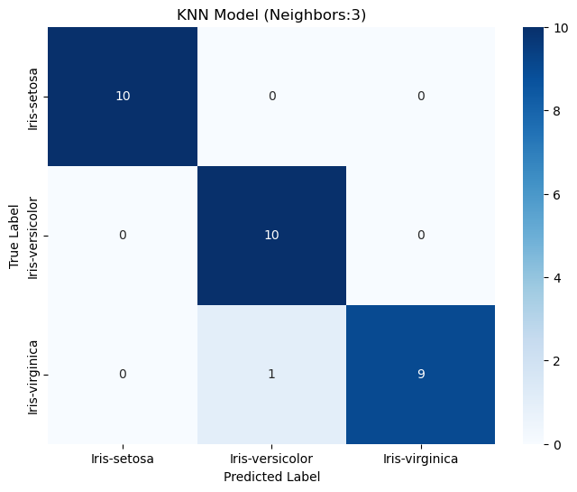

```
Accuracy: 0.9667
Sensitivity (Macro Recall): 0.9667
Specificity (Macro Specificity): 0.9833
Precision (Macro): 0.9697
F1 Score: 0.9666

Classification Report:
                  precision    recall  f1-score   support

    Iris-setosa       1.00      1.00      1.00        10
Iris-versicolor       0.91      1.00      0.95        10
 Iris-virginica       1.00      0.90      0.95        10

       accuracy                           0.97        30
      macro avg       0.97      0.97      0.97        30
   weighted avg       0.97      0.97      0.97        30
```

```python
neighbors = 3
create_report(y_test, train_KNN(neighbors,X_train,y_train,X_test), label_encoder.classes_, f"KNN Model (Neighbors:{neighbors})")
```

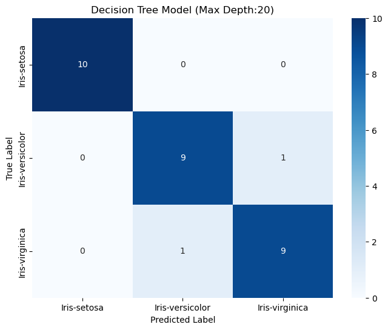

```
Accuracy: 0.9333
Sensitivity (Macro Recall): 0.9333
Specificity (Macro Specificity): 0.9667
Precision (Macro): 0.9333
F1 Score: 0.9333

Classification Report:
                  precision    recall  f1-score   support

    Iris-setosa       1.00      1.00      1.00        10
Iris-versicolor       0.90      0.90      0.90        10
 Iris-virginica       0.90      0.90      0.90        10

       accuracy                           0.93        30
      macro avg       0.93      0.93      0.93        30
   weighted avg       0.93      0.93      0.93        30
```

```python
depth = 20
create_report(y_test, train_decision_tree(depth,X_train,y_train,X_test), label_encoder.classes_, f"Decision Tree Model (Max Depth:{depth})")
```

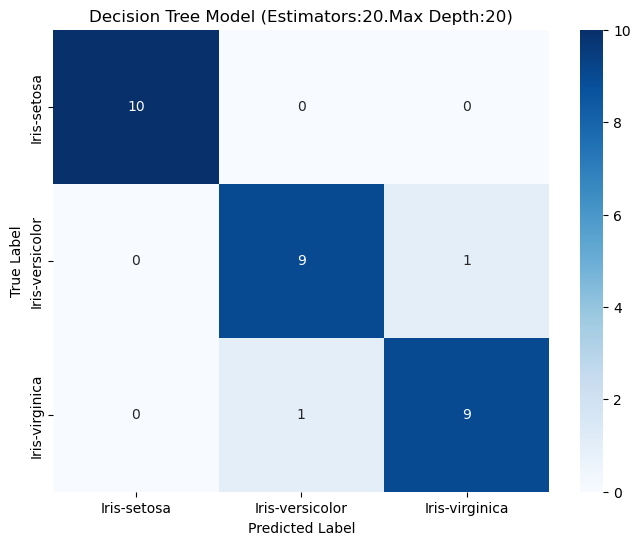

```
Accuracy: 0.9333
Sensitivity (Macro Recall): 0.9333
Specificity (Macro Specificity): 0.9667
Precision (Macro): 0.9333
F1 Score: 0.9333

Classification Report:
                  precision    recall  f1-score   support

    Iris-setosa       1.00      1.00      1.00        10
Iris-versicolor       0.90      0.90      0.90        10
 Iris-virginica       0.90      0.90      0.90        10

       accuracy                           0.93        30
      macro avg       0.93      0.93      0.93        30
   weighted avg       0.93      0.93      0.93        30
```

```python
depth = 20
estimators = 20
create_report(y_test, train_random_forest(estimators,depth,X_train,y_train,X_test), label_encoder.classes_, f"Decision Tree Model (Estimators:{estimators}.Max Depth:{depth})")
```

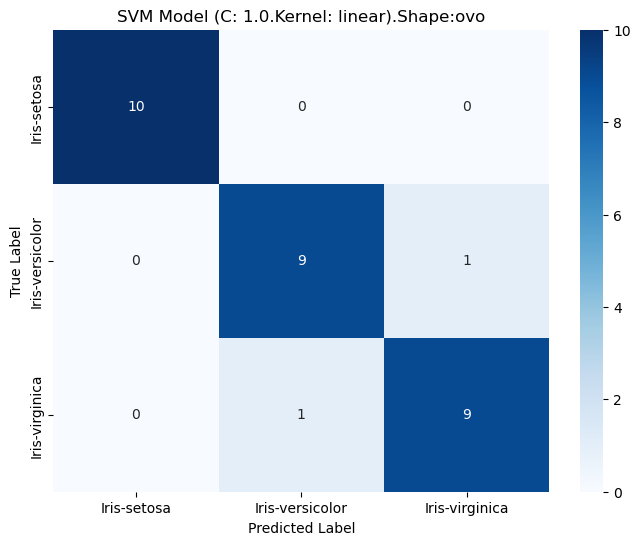

```
Accuracy: 0.9333
Sensitivity (Macro Recall): 0.9333
Specificity (Macro Specificity): 0.9667
Precision (Macro): 0.9333
F1 Score: 0.9333

Classification Report:
                  precision    recall  f1-score   support

    Iris-setosa       1.00      1.00      1.00        10
Iris-versicolor       0.90      0.90      0.90        10
 Iris-virginica       0.90      0.90      0.90        10

       accuracy                           0.93        30
      macro avg       0.93      0.93      0.93        30
   weighted avg       0.93      0.93      0.93        30
```

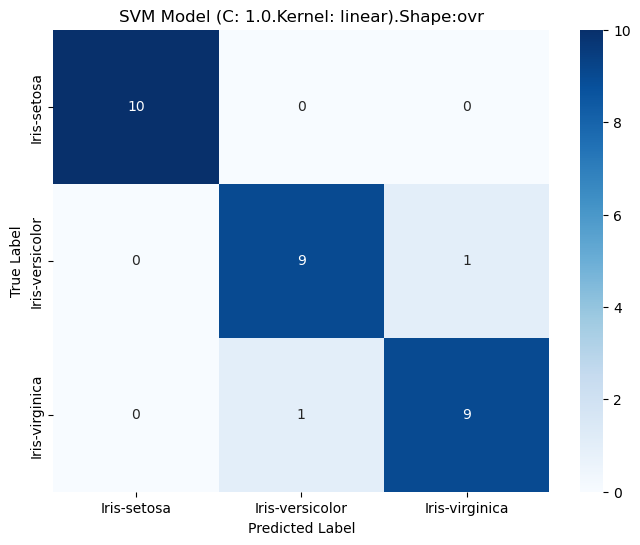

```
Accuracy: 0.9333
Sensitivity (Macro Recall): 0.9333
Specificity (Macro Specificity): 0.9667
Precision (Macro): 0.9333
F1 Score: 0.9333

Classification Report:
                  precision    recall  f1-score   support

    Iris-setosa       1.00      1.00      1.00        10
Iris-versicolor       0.90      0.90      0.90        10
 Iris-virginica       0.90      0.90      0.90        10

       accuracy                           0.93        30
      macro avg       0.93      0.93      0.93        30
   weighted avg       0.93      0.93      0.93        30
```

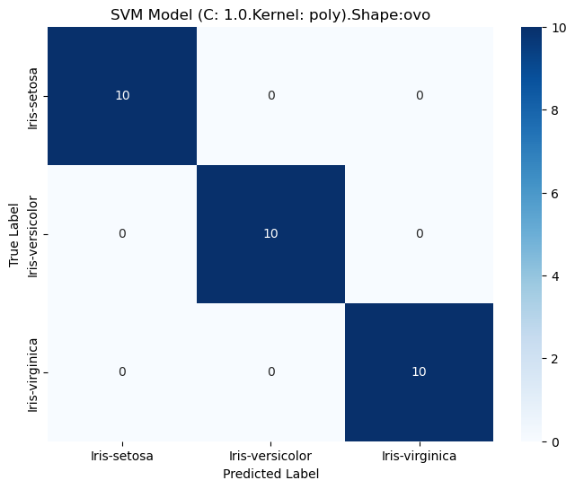

```
Accuracy: 1.0000
Sensitivity (Macro Recall): 1.0000
Specificity (Macro Specificity): 1.0000
Precision (Macro): 1.0000
F1 Score: 1.0000

Classification Report:
                  precision    recall  f1-score   support

    Iris-setosa       1.00      1.00      1.00        10
Iris-versicolor       1.00      1.00      1.00        10
 Iris-virginica       1.00      1.00      1.00        10

       accuracy                           1.00        30
      macro avg       1.00      1.00      1.00        30
   weighted avg       1.00      1.00      1.00        30
```

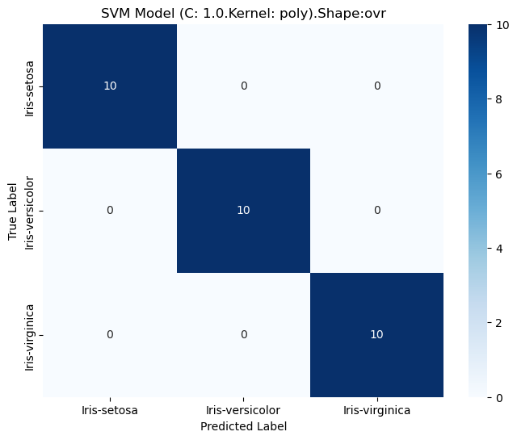

```
Accuracy: 1.0000
Sensitivity (Macro Recall): 1.0000
Specificity (Macro Specificity): 1.0000
Precision (Macro): 1.0000
F1 Score: 1.0000

Classification Report:
                  precision    recall  f1-score   support

    Iris-setosa       1.00      1.00      1.00        10
Iris-versicolor       1.00      1.00      1.00        10
 Iris-virginica       1.00      1.00      1.00        10

       accuracy                           1.00        30
      macro avg       1.00      1.00      1.00        30
   weighted avg       1.00      1.00      1.00        30
```

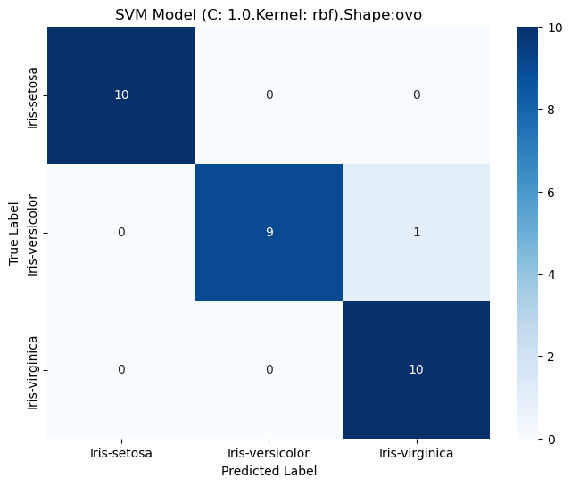

```
Accuracy: 0.9667
Sensitivity (Macro Recall): 0.9667
Specificity (Macro Specificity): 0.9833
Precision (Macro): 0.9697
F1 Score: 0.9666

Classification Report:
                  precision    recall  f1-score   support

    Iris-setosa       1.00      1.00      1.00        10
Iris-versicolor       1.00      0.90      0.95        10
 Iris-virginica       0.91      1.00      0.95        10

       accuracy                           0.97        30
      macro avg       0.97      0.97      0.97        30
   weighted avg       0.97      0.97      0.97        30
```

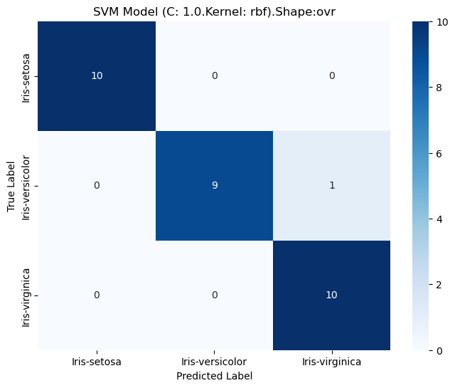

```
Accuracy: 0.9667
Sensitivity (Macro Recall): 0.9667
Specificity (Macro Specificity): 0.9833
Precision (Macro): 0.9697
F1 Score: 0.9666

Classification Report:
                  precision    recall  f1-score   support

    Iris-setosa       1.00      1.00      1.00        10
Iris-versicolor       1.00      0.90      0.95        10
 Iris-virginica       0.91      1.00      0.95        10

       accuracy                           0.97        30
      macro avg       0.97      0.97      0.97        30
   weighted avg       0.97      0.97      0.97        30
```

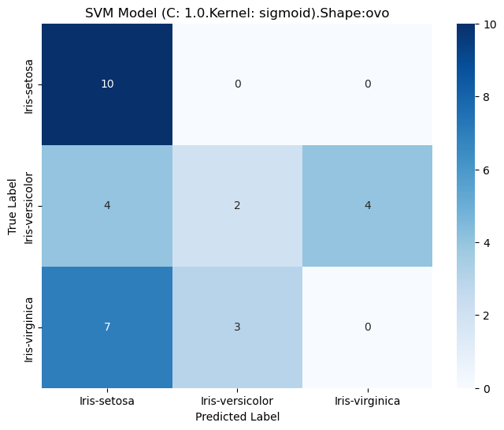

```
Accuracy: 0.4000
Sensitivity (Macro Recall): 0.4000
Specificity (Macro Specificity): 0.7000
Precision (Macro): 0.2921
F1 Score: 0.3039

Classification Report:
                  precision    recall  f1-score   support

    Iris-setosa       0.48      1.00      0.65        10
Iris-versicolor       0.40      0.20      0.27        10
 Iris-virginica       0.00      0.00      0.00        10

       accuracy                           0.40        30
      macro avg       0.29      0.40      0.30        30
   weighted avg       0.29      0.40      0.30        30
```

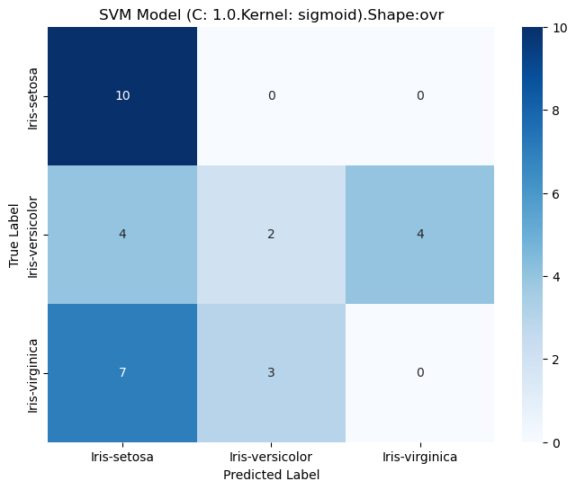

```
Accuracy: 0.4000
Sensitivity (Macro Recall): 0.4000
Specificity (Macro Specificity): 0.7000
Precision (Macro): 0.2921
F1 Score: 0.3039

Classification Report:
                  precision    recall  f1-score   support

    Iris-setosa       0.48      1.00      0.65        10
Iris-versicolor       0.40      0.20      0.27        10
 Iris-virginica       0.00      0.00      0.00        10

       accuracy                           0.40        30
      macro avg       0.29      0.40      0.30        30
   weighted avg       0.29      0.40      0.30        30
```

```python
mode = ['linear', 'poly', 'rbf', 'sigmoid']
shape = ['ovo', 'ovr']
for mod in mode:
    for shap in shape:
        create_report(y_test,
                    train_svm(1,mod,shap,X_train,y_train,X_test),
                    label_encoder.classes_,
                    f"SVM Model (C: 1.0.Kernel: {mod}).Shape:{shap}")
```

```python
# Let play around with hyper parameters
results = {}
for neighbor in range(1,11,1):
    results[f"KNN_{neighbor}"] = extract_result(y_test, train_KNN(neighbors,X_train,y_train,X_test))
for depth in range(1,6,1):
    results[f"DT_{depth}"] = extract_result(y_test, train_decision_tree(depth,X_train,y_train,X_test))
for estimators in range(1, 6, 1):
    for depth in range(1,6,1):
        results[f"RF_E{estimators}_D{depth}"] = extract_result(y_test, train_random_forest(estimators,depth,X_train,y_train,X_test))
for c in range(7):
    for mode in ['linear', 'poly', 'rbf', 'sigmoid']:
        for shape in ['ovo', 'ovr']:
            results[f"SVM_C{10**c}_{mode.upper()}_{shape.upper()}"] = extract_result(y_test,
                                                                                    train_svm(10**c,mode,shape,X_train,y_train,X_test))
```

```python
# Tabulate accuracy, sensitivity, specificity, precision, f1 scores

# Prepare data for tabulation
table_data = []
for model_name, metrics in results.items():
    table_data.append([
        model_name,
        f"{metrics['accuracy']:.4f}",
        f"{metrics['sensitivity']:.4f}",
        f"{metrics['specificity']:.4f}",
        f"{metrics['precision']:.4f}",
        f"{metrics['f1_score']:.4f}",
        f"{metrics['overall']:.4f}"
    ])

# Define headers
headers = ["Model", "Accuracy", "Sensitivity", "Specificity", "Precision", "F1 Score","Overall"]

# Print the table
table = tabulate(table_data, headers=headers, tablefmt="fancy_grid")
print(table)
```

```
╒══════════════════════════╤════════════╤═══════════════╤═══════════════╤═════════════╤════════════╤═══════════╕
│ Model                    │   Accuracy │   Sensitivity │   Specificity │   Precision │   F1 Score │   Overall │
╞══════════════════════════╪════════════╪═══════════════╪═══════════════╪═════════════╪════════════╪═══════════╡
│ KNN_1                    │     0.9667 │        0.9667 │        0.9833 │      0.9697 │     0.9666 │    0.9706 │
├──────────────────────────┼────────────┼───────────────┼───────────────┼─────────────┼────────────┼───────────┤
│ KNN_2                    │     0.9667 │        0.9667 │        0.9833 │      0.9697 │     0.9666 │    0.9706 │
├──────────────────────────┼────────────┼───────────────┼───────────────┼─────────────┼────────────┼───────────┤
│ KNN_3                    │     0.9667 │        0.9667 │        0.9833 │      0.9697 │     0.9666 │    0.9706 │
├──────────────────────────┼────────────┼───────────────┼───────────────┼─────────────┼────────────┼───────────┤
│ KNN_4                    │     0.9667 │        0.9667 │        0.9833 │      0.9697 │     0.9666 │    0.9706 │
├──────────────────────────┼────────────┼───────────────┼───────────────┼─────────────┼────────────┼───────────┤
│ KNN_5                    │     0.9667 │        0.9667 │        0.9833 │      0.9697 │     0.9666 │    0.9706 │
├──────────────────────────┼────────────┼───────────────┼───────────────┼─────────────┼────────────┼───────────┤
│ KNN_6                    │     0.9667 │        0.9667 │        0.9833 │      0.9697 │     0.9666 │    0.9706 │
├──────────────────────────┼────────────┼───────────────┼───────────────┼─────────────┼────────────┼───────────┤
│ KNN_7                    │     0.9667 │        0.9667 │        0.9833 │      0.9697 │     0.9666 │    0.9706 │
├──────────────────────────┼────────────┼───────────────┼───────────────┼─────────────┼────────────┼───────────┤
│ KNN_8                    │     0.9667 │        0.9667 │        0.9833 │      0.9697 │     0.9666 │    0.9706 │
├──────────────────────────┼────────────┼───────────────┼───────────────┼─────────────┼────────────┼───────────┤
│ KNN_9                    │     0.9667 │        0.9667 │        0.9833 │      0.9697 │     0.9666 │    0.9706 │
├──────────────────────────┼────────────┼───────────────┼───────────────┼─────────────┼────────────┼───────────┤
│ KNN_10                   │     0.9667 │        0.9667 │        0.9833 │      0.9697 │     0.9666 │    0.9706 │
├──────────────────────────┼────────────┼───────────────┼───────────────┼─────────────┼────────────┼───────────┤
│ DT_1                     │     0.6667 │        0.6667 │        0.8333 │      0.5    │     0.5556 │    0.6444 │
├──────────────────────────┼────────────┼───────────────┼───────────────┼─────────────┼────────────┼───────────┤
│ DT_2                     │     0.9333 │        0.9333 │        0.9667 │      0.9333 │     0.9333 │    0.94   │
├──────────────────────────┼────────────┼───────────────┼───────────────┼─────────────┼────────────┼───────────┤
│ DT_3                     │     0.9667 │        0.9667 │        0.9833 │      0.9697 │     0.9666 │    0.9706 │
├──────────────────────────┼────────────┼───────────────┼───────────────┼─────────────┼────────────┼───────────┤
│ DT_4                     │     0.9333 │        0.9333 │        0.9667 │      0.9333 │     0.9333 │    0.94   │
├──────────────────────────┼────────────┼───────────────┼───────────────┼─────────────┼────────────┼───────────┤
│ DT_5                     │     0.9333 │        0.9333 │        0.9667 │      0.9333 │     0.9333 │    0.94   │
├──────────────────────────┼────────────┼───────────────┼───────────────┼─────────────┼────────────┼───────────┤
│ RF_E1_D1                 │     0.6667 │        0.6667 │        0.8333 │      0.5    │     0.5556 │    0.6444 │
├──────────────────────────┼────────────┼───────────────┼───────────────┼─────────────┼────────────┼───────────┤
│ RF_E1_D2                 │     0.9    │        0.9    │        0.95   │      0.9024 │     0.8997 │    0.9104 │
├──────────────────────────┼────────────┼───────────────┼───────────────┼─────────────┼────────────┼───────────┤
│ RF_E1_D3                 │     0.9333 │        0.9333 │        0.9667 │      0.9444 │     0.9327 │    0.9421 │
├──────────────────────────┼────────────┼───────────────┼───────────────┼─────────────┼────────────┼───────────┤
│ RF_E1_D4                 │     0.9667 │        0.9667 │        0.9833 │      0.9697 │     0.9666 │    0.9706 │
```

[output cut: 140 more lines]

```
├──────────────────────────┼────────────┼───────────────┼───────────────┼─────────────┼────────────┼───────────┤
│ SVM_C1000000_LINEAR_OVR  │     1      │        1      │        1      │      1      │     1      │    1      │
├──────────────────────────┼────────────┼───────────────┼───────────────┼─────────────┼────────────┼───────────┤
│ SVM_C1000000_POLY_OVO    │     1      │        1      │        1      │      1      │     1      │    1      │
├──────────────────────────┼────────────┼───────────────┼───────────────┼─────────────┼────────────┼───────────┤
│ SVM_C1000000_POLY_OVR    │     1      │        1      │        1      │      1      │     1      │    1      │
├──────────────────────────┼────────────┼───────────────┼───────────────┼─────────────┼────────────┼───────────┤
│ SVM_C1000000_RBF_OVO     │     0.9333 │        0.9333 │        0.9667 │      0.9333 │     0.9333 │    0.94   │
├──────────────────────────┼────────────┼───────────────┼───────────────┼─────────────┼────────────┼───────────┤
│ SVM_C1000000_RBF_OVR     │     0.9333 │        0.9333 │        0.9667 │      0.9333 │     0.9333 │    0.94   │
├──────────────────────────┼────────────┼───────────────┼───────────────┼─────────────┼────────────┼───────────┤
│ SVM_C1000000_SIGMOID_OVO │     0.2333 │        0.2333 │        0.6167 │      0.1389 │     0.1732 │    0.2791 │
├──────────────────────────┼────────────┼───────────────┼───────────────┼─────────────┼────────────┼───────────┤
│ SVM_C1000000_SIGMOID_OVR │     0.2333 │        0.2333 │        0.6167 │      0.1389 │     0.1732 │    0.2791 │
╘══════════════════════════╧════════════╧═══════════════╧═══════════════╧═════════════╧════════════╧═══════════╛
```